# Reproducible Research Project 1

Papajohnco

12/12/2021-12/28/2021

## Load dplyr, ggplot2, and knitr packages then call the libraries to this session

```r
library(knitr)
library(dplyr)
```

```r
library(ggplot2)
library(lattice)
```

## Global enable to alway show code chunks in output

```r
opts_chunk$set(echo = TRUE)
```

## Set working directory

```r
setwd("C:/Users/jcomaiii/Desktop/Coursera Reproducible Research/Reproducible-Research-Repo")
```

## Read the data into Rstudio using the read.csv function and assign a object name “data_rows”

```r
data_rows <- read.csv("activity.csv")
```

## Remove NA from data and assign a object name “data” *could also use na.rm = TRUE

```r
data <- data_rows [ with (data_rows, { !(is.na(steps)) } ), ]
```

## View first 30 rows without “NA” to ensure that NA is removed

```r
head(data, 30)
```

```
##     steps       date interval
## 289     0 2012-10-02        0
## 290     0 2012-10-02        5
## 291     0 2012-10-02       10
## 292     0 2012-10-02       15
## 293     0 2012-10-02       20
## 294     0 2012-10-02       25
## 295     0 2012-10-02       30
## 296     0 2012-10-02       35
## 297     0 2012-10-02       40
## 298     0 2012-10-02       45
## 299     0 2012-10-02       50
## 300     0 2012-10-02       55
## 301     0 2012-10-02      100
## 302     0 2012-10-02      105
```

[output cut: 16 more lines]

## Adding total steps each day by date using aggregate function

```r
aggregate(x = data$steps, by = list(data$date), FUN = sum)
```

```
##       Group.1     x
## 1  2012-10-02   126
## 2  2012-10-03 11352
## 3  2012-10-04 12116
## 4  2012-10-05 13294
## 5  2012-10-06 15420
## 6  2012-10-07 11015
## 7  2012-10-09 12811
## 8  2012-10-10  9900
## 9  2012-10-11 10304
## 10 2012-10-12 17382
## 11 2012-10-13 12426
## 12 2012-10-14 15098
## 13 2012-10-15 10139
## 14 2012-10-16 15084
```

[output cut: 39 more lines]

## could also calculate total number of steps taken per day as follows

```r
by_day <- group_by(data, date)
steps_by_day <- summarise(by_day, total = sum(steps))
steps_by_day
```

```
## # A tibble: 53 x 2
##    date       total
##    <chr>      <int>
##  1 2012-10-02   126
##  2 2012-10-03 11352
##  3 2012-10-04 12116
##  4 2012-10-05 13294
##  5 2012-10-06 15420
##  6 2012-10-07 11015
##  7 2012-10-09 12811
##  8 2012-10-10  9900
##  9 2012-10-11 10304
## 10 2012-10-12 17382
## # ... with 43 more rows
```

## Assign total number of steps taken each day to variable x

```r
x <- aggregate(x = data$steps, by = list(data$date), FUN = sum)
```

## Histogram of the total number of steps taken each day

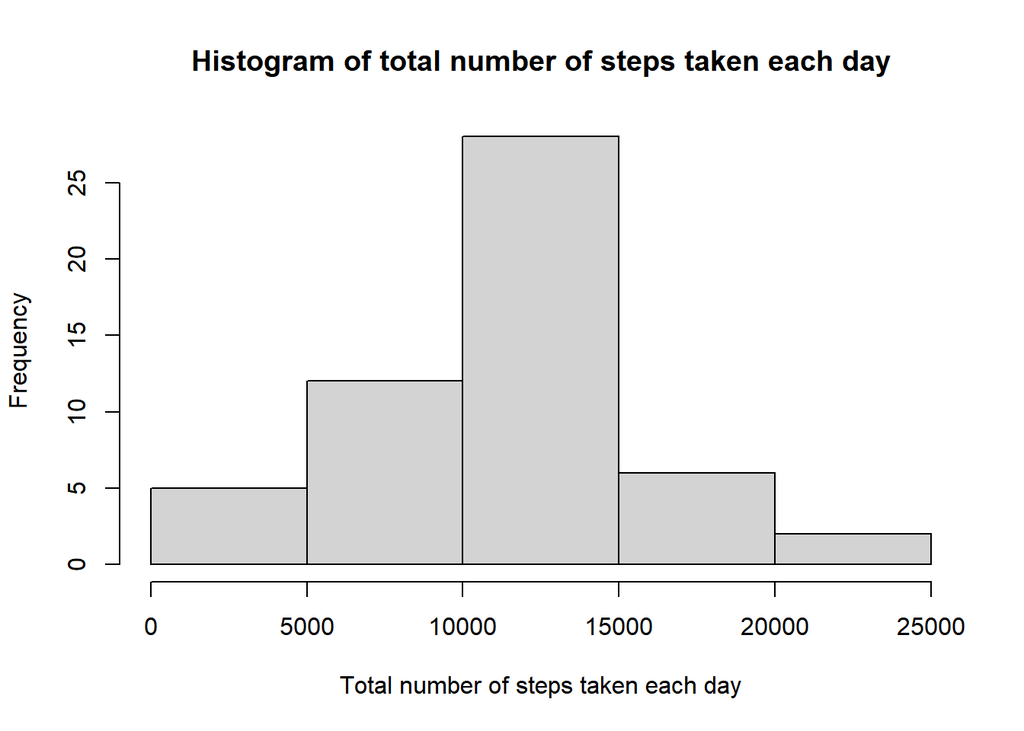

```r
hist(steps_by_day$total, main="Histogram of total number of steps taken each day",
     xlab="Total number of steps taken each day")
```

## Calculate and report the mean and median of the total number of steps taken per day using summary feature

```r
summary(steps_by_day)
```

```
##      date               total
##  Length:53          Min.   :   41
##  Class :character   1st Qu.: 8841
##  Mode  :character   Median :10765
##                     Mean   :10766
##                     3rd Qu.:13294
##                     Max.   :21194
```

## Preprocessing data for time series plot (i.e. type = “l”)

```r
steps_by_interval <- aggregate(steps ~ interval, data, mean)
```

## Create the time series plot

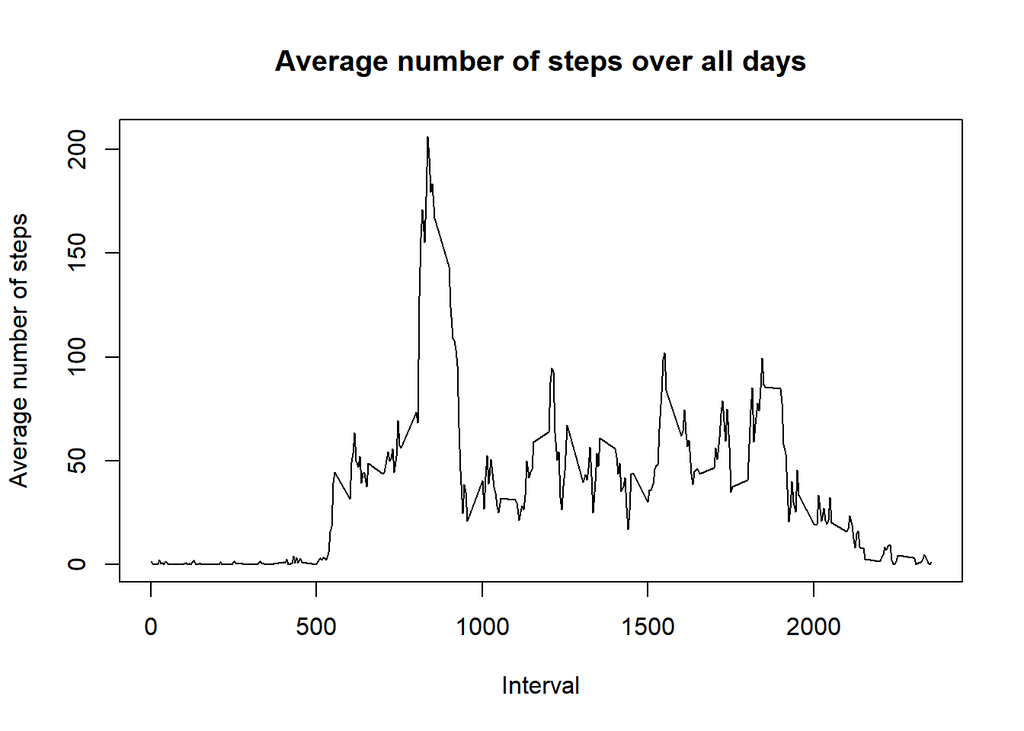

```r
plot(steps_by_interval$interval, steps_by_interval$steps, type='l',
     main="Average number of steps over all days",
     xlab="Interval",
     ylab="Average number of steps")
```

## Process the data to determine which 5-minute interval, on average across all the days in the dataset, contains the maximum number of steps?

```r
max_steps_row <- which.max(steps_by_interval$steps)
```

## Calculate the interval that has the average max steps row value

```r
steps_by_interval[max_steps_row, ]
```

```
##     interval    steps
## 104      835 206.1698
```

## Therefore the interval that contains the max number of steps is 835, which has average max of just over 206 steps

## Imputing missing values. ie. Calculate and report the total number of missing values in the dataset

```r
sum(is.na(data_rows))
```

```
## [1] 2304
```

## The total number of rows with NA is 2304

```r
missingIndex<-is.na(data_rows[,1])
```

```r
m<-mean(steps_by_interval$steps)
```

## Create a new dataset with the missing (imputed) data filled in.

```r
activity1<-data_rows
activity1[missingIndex,1]<-m
head(activity1)
```

```
##     steps       date interval
## 1 37.3826 2012-10-01        0
## 2 37.3826 2012-10-01        5
## 3 37.3826 2012-10-01       10
## 4 37.3826 2012-10-01       15
## 5 37.3826 2012-10-01       20
## 6 37.3826 2012-10-01       25
```

## Histogram of the total number of steps taken each day after imputed data is included

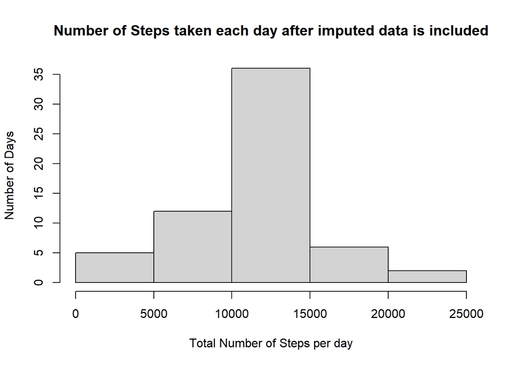

```r
totalStepsByDay1<-aggregate(steps~date, activity1, sum)
hist(totalStepsByDay1$steps, xlab="Total Number of Steps per day", ylab="Number of Days", main="Number of Steps taken each day after imputed data is included")
```

```r
total_Steps_By_Day1<-aggregate(steps~date, activity1, sum)
```

## Mean after imputed steps added

```r
mean_after_imputed_steps<-mean(total_Steps_By_Day1$steps)
mean_after_imputed_steps
```

```
## [1] 10766.19
```

## Median after imputed steps added

```r
median_after_imputed_steps<-median(total_Steps_By_Day1$steps)
median_after_imputed_steps
```

```
## [1] 10766.19
```

## Using the new dataset with imputed data “activity1”, create new variables “weekday” and “weekend”

## If day is Saturday or Sunday then it’s weekend, else it’s a weekday

## Create these variables in “activity2”

```r
activity1$date<-as.Date(activity1$date)
activity2<-activity1%>%
  mutate(daytype= ifelse(weekdays(activity1$date)=="Saturday"|weekdays(activity1$date)=="Sunday", "Weekend", "Weekday"))
head(activity2, 10)
```

```
##      steps       date interval daytype
## 1  37.3826 2012-10-01        0 Weekday
## 2  37.3826 2012-10-01        5 Weekday
## 3  37.3826 2012-10-01       10 Weekday
## 4  37.3826 2012-10-01       15 Weekday
## 5  37.3826 2012-10-01       20 Weekday
## 6  37.3826 2012-10-01       25 Weekday
## 7  37.3826 2012-10-01       30 Weekday
## 8  37.3826 2012-10-01       35 Weekday
## 9  37.3826 2012-10-01       40 Weekday
## 10 37.3826 2012-10-01       45 Weekday
```

```r
averageStepByDayTypeAndInterval<-activity2%>%
  group_by(daytype, interval)%>%
  summarize(averageStepByDay=sum(steps))
```

[figure not shown]

```r
with(averageStepByDayTypeAndInterval,
      xyplot(averageStepByDay ~ interval | daytype,
      type = "l",
      main = "Average Number of Steps across Weekdays & Weekends",
      xlab = "Daily Intervals",
      ylab = "Average Number of Steps"))
```